# Machine learning no estudo da dinâmica conformacional de proteinas

MSc. João Pedro Fernandes Queiroz[^1]

Orientador Prof. Dr. Bruno Anderson Matias da Rocha[^2]

Colaborador Prof. Dr. José Maria da Silva Monteiro Filho[^3]

# Introdução

Proteínas estão entre as macromoléculas mais estudadas no campo da Bioquímica por desempenharem diversos processos essenciais para a vida na Terra. Um dos princípios mais importantes da bioquímica diz respeito à relação entre a estrutura molecular e a função de uma proteína. No entanto, proteínas não são moléculas estáticas. Elas se movimentam; mudam a própria conformação ao longo do tempo. Portanto, para entendermos satisfatoriamente como a estrutura de uma proteína determina a sua função, precisamos conhecer os meandros conformacionais pelos quais a estrutura de uma proteína navega durante um intervalo de tempo.

Extrair informação sobre os padrões conformacionais de um conjunto de dados de proteínas não é uma tarefa fácil. Cada proteína possui uma grande quantidade de resíduos de aminoácidos, que por sua vez possuem uma vasta gama de estados conformacionais. A análise de componente principal (PCA) é um algoritmo capaz de reduzir a dimensionalidade de um conjunto de dados ao mesmo tempo que retém a sua variabilidade (RINGNÉR, 2008). O objetivo do presente projeto é aplicar a PCA no estudo da variação conformacional de famílias de proteínas. Identificando componentes principais ao longo dos quais a variação dos dados é máxima, buscamos avaliar as similaridades e diferenças entre famílias de proteínas. Utilizando algoritmos de *machine learning*, tentaremos agrupar as proteínas de forma a facilitar na identificação de diferenças conformacionais entre grupos, diferenças estas potencialmente importantes para explicar a variação na função proteica.

# Parte I: extração de dados

O Protein Data Bank (PDB) (https://www.rcsb.org/) é a principal base de dados de estruturas de macromoléculas biológicas determinadas experimentalmente. Iremos baixar as estruturas de proteínas em formato PDB para quaisquer família de proteínas de interesse utilizando o algoritmo BLAST (ALTSCHUL et al., 1990) através do pacote Bio3D (versão 2.4-3) (GRANT et al., 2006; GRANT; SKJÆRVEN; YAO, 2020; SKJÆRVEN et al., 2014) para a linguagem R (versão 4.1.1) (R CORE TEAM, 2021). O pacote Bio3D possui funções para manipulação de estruturas moleculares em formato PDB, incluindo alinhamento e sobreposição estrutural baseados em sequências executando o software MUSCLE (EDGAR, 2004) como aplicação externa para o alinhamento das sequências, ou baseado em estrutura executando o software MUSTANG (KONAGURTHU et al., 2006) para a produção do alinhamento por meio do ajuste estrutural. A família de proteínas estruturalmente sobreposta será usada para a PCA a fim de obtermos os componentes principais que irão compor o *dataset* que iremos utilizar nas etapas seguintes do projeto.

O *ensemble* — “conjunto cujos elementos são sistemas de partículas que servem para descrever um único sistema dado” [Oxford Languages] — PCA é baseado na diagonalização da matriz de covariância, $C$, com elementos $C_{ij}$ calculados a partir das coordenadas cartesianas alinhadas e sobrepostas, $r$, dos átomos de C$\alpha$:

$$C_{ij} = \langle(r_i-\langle r_j \rangle)\times(r_j- \langle r_j \rangle) \rangle$$

onde i e j enumeram todas as 3 $N$ coordenadas cartesianas ($N$ é o número de átomos), e $\langle r \rangle$ denota a média do ensemble. Projetar a distribuição no subespaço definido pelos componentes principais com os maiores autovalores fornece uma representação das estruturas com reduzida dimensionalidade, facilitando a análise dos diferentes confôrmeros.

No presente trabalho iremos analisar a família de proteínas das lectinas de plantas leguminosas da subtribo Diocleinae.

## Lectinas de leguminosas

O chunk de código abaixo inclui os principais pacotes a serem carregados.

```r
# Necessary packages
library(bio3d)
```

Para realizarmos a sobreposição estrutural baseada no alinhamento de sequências, precisamos que o software MUSCLE esteja instalado e precisamos usar o path para o executável como argumento na função do Bio3D que irá submeter as sequências e os parâmetros do alinhamento ao MUSCLE.

```r
# MUSCLE executable file path
file.path("D:", "Biblioteca", "R scripts", "Multiple Sequence Alignment",
"muscle3.8.31_i86win32.exe") -> fp.muscle
```

Para baixarmos as estruturas do PDB, iremos executar o algoritmo BLAST usando como isca a estrutura da ConA, uma das mais bem conhecidas e estudas lectinas de leguminosas.

```r
# Search for related structures
aa <- get.seq("2CNA")
```

```
## Fetching... Please wait. Done.
```

```r
blast <- blast.pdb(aa)
```

```
##  Searching ... please wait (updates every 5 seconds) RID = 8XM8X3EE013
##  ............
##  Reporting 188 hits
```

```
##   * Possible cutoff values:    303 -3
##             Yielding Nhits:    34 188
##
##   * Chosen cutoff value of:    303
##             Yielding Nhits:    34
```

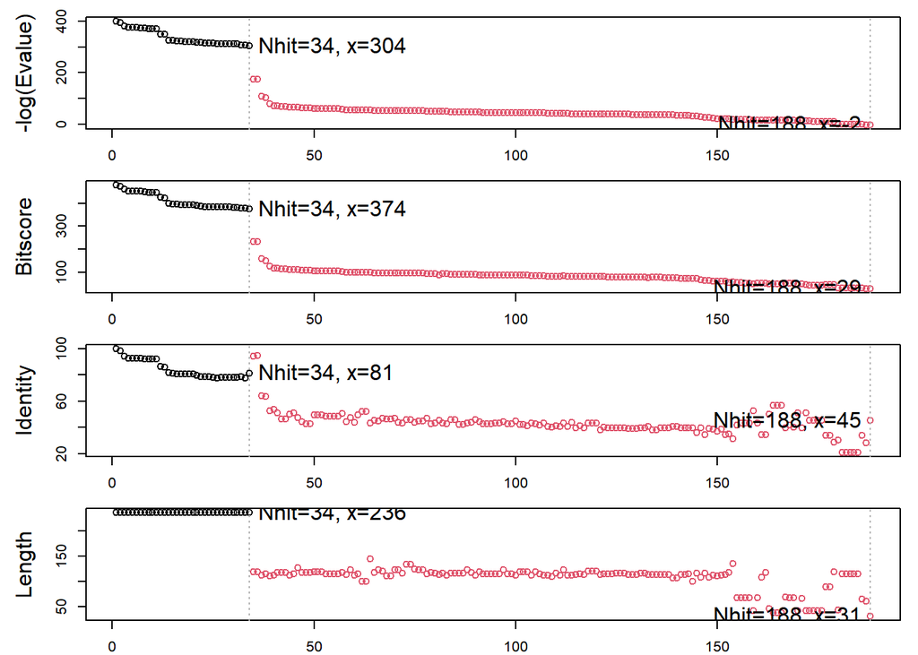

```r
hits <- plot.blast(blast, cutoff = 303)
```

```r
# Download metadata for hits from PDB
annotation <- pdb.annotate(hits)
```

Após verificar os hits, observamos que os 34 selecionados de acordo com o cutoff sugerido são estruturas de lectinas de leguminosas da subtribo Diocleinae, enquanto que os hits não selecionados correspondem a lectinas de leguminosas que não fazem parte da subtribo Diocleinae. Com isso, iremos realizar o download dos 34 hits.

```r
## Download and split by chain ID
files <- get.pdb(hits, path = "Diocleinae_3D_structures", split = TRUE)
```

Agora iremos realizar o alinhamento de sequências e sobreposição estrutural para o monômero separado de cada lectina, salvando as estruturas com as novas coordenadas no final.

```r
# Structure/sequence alignment
pdbs <- pdbaln(files, fit=TRUE, exefile = fp.muscle)
```

[output not shown]

[output cut: 36 more lines]

```
## pdb/seq: 25   name: Diocleinae_3D_structures/split_chain/7LJG_A.pdb
##    PDB has ALT records, taking A only, rm.alt=TRUE
## pdb/seq: 26   name: Diocleinae_3D_structures/split_chain/5TG3_A.pdb
## pdb/seq: 27   name: Diocleinae_3D_structures/split_chain/2JE9_A.pdb
##    PDB has ALT records, taking A only, rm.alt=TRUE
## pdb/seq: 28   name: Diocleinae_3D_structures/split_chain/3SH3_A.pdb
##    PDB has ALT records, taking A only, rm.alt=TRUE
## pdb/seq: 29   name: Diocleinae_3D_structures/split_chain/4NOT_A.pdb
## pdb/seq: 30   name: Diocleinae_3D_structures/split_chain/3U4X_A.pdb
## pdb/seq: 31   name: Diocleinae_3D_structures/split_chain/4Z8B_A.pdb
##    PDB has ALT records, taking A only, rm.alt=TRUE
## pdb/seq: 32   name: Diocleinae_3D_structures/split_chain/1MVQ_A.pdb
##    PDB has ALT records, taking A only, rm.alt=TRUE
## pdb/seq: 33   name: Diocleinae_3D_structures/split_chain/2D3P_A.pdb
## pdb/seq: 34   name: Diocleinae_3D_structures/split_chain/3A0K_A.pdb
```

```r
# Core identification
core <- core.find(pdbs)
```

[output not shown]

[output cut: 72 more lines]

```
##  core size 102 of 215  vol = 0.637
##  core size 101 of 215  vol = 0.624
##  core size 100 of 215  vol = 0.612
##  core size 99 of 215  vol = 0.601
##  core size 98 of 215  vol = 0.59
##  core size 97 of 215  vol = 0.578
##  core size 96 of 215  vol = 0.567
##  core size 95 of 215  vol = 0.557
##  core size 94 of 215  vol = 0.545
##  core size 93 of 215  vol = 0.534
##  core size 92 of 215  vol = 0.524
##  core size 91 of 215  vol = 0.513
##  core size 90 of 215  vol = 0.504
##  core size 89 of 215  vol = 0.494
##  FINISHED: Min vol ( 0.5 ) reached
```

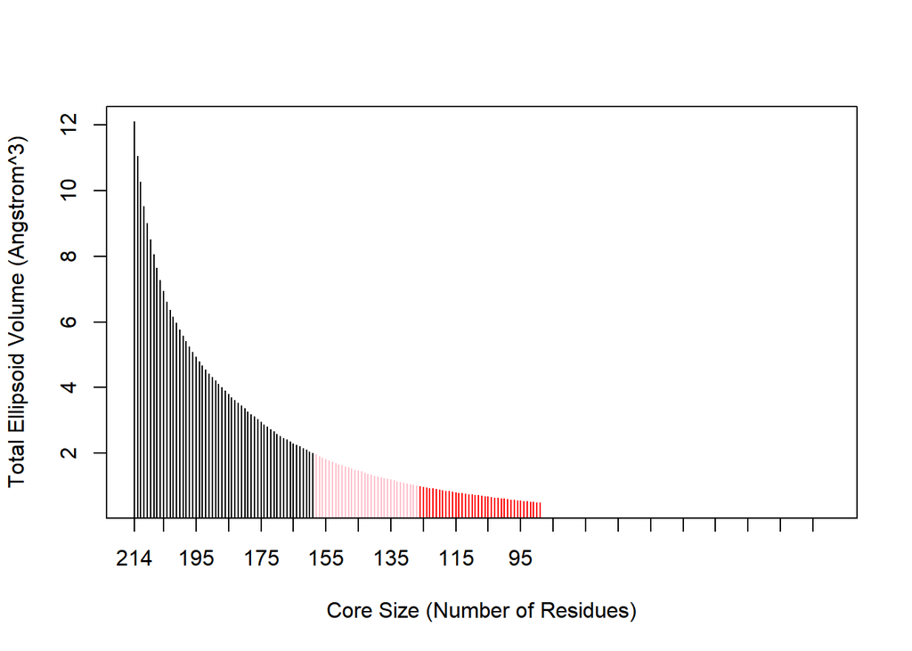

```r
# Plot core
col=rep("black", length(core$volume))
col[core$volume<2]="pink"; col[core$volume<1]="red"
plot(core, col=col)
```

```r
# Visualize core
core.inds <- print(core, vol=1.0)
```

```
## # 127 positions (cumulative volume <= 1 Angstrom^3)
##    start end length
## 1      3   9      7
## 2     23  39     17
## 3     46  54      9
## 4     59  66      8
## 5     73  78      6
## 6     85  96     12
## 7    104 113     10
## 8    125 130      6
## 9    139 147      9
## 10   154 157      4
## 11   169 179     11
## 12   190 199     10
## 13   210 221     12
## 14   228 233      6
```

```r
# Write the core and the superimposed structures
write.pdb(xyz=pdbs$xyz[1,core.inds$xyz], file="quick_core.pdb")
xyz <- pdbfit(pdbs, core.inds, outpath = "core_ensemble")
```

[output not shown]

O alinhamento mostra 215 sítios equivalentes e sem lacunas, ou seja, temos 215 átomos de C$\alpha$ equivalentes, onde iremos realizar a PCA e visualizar uma projeção preliminar dos três primeiros componentes principais.

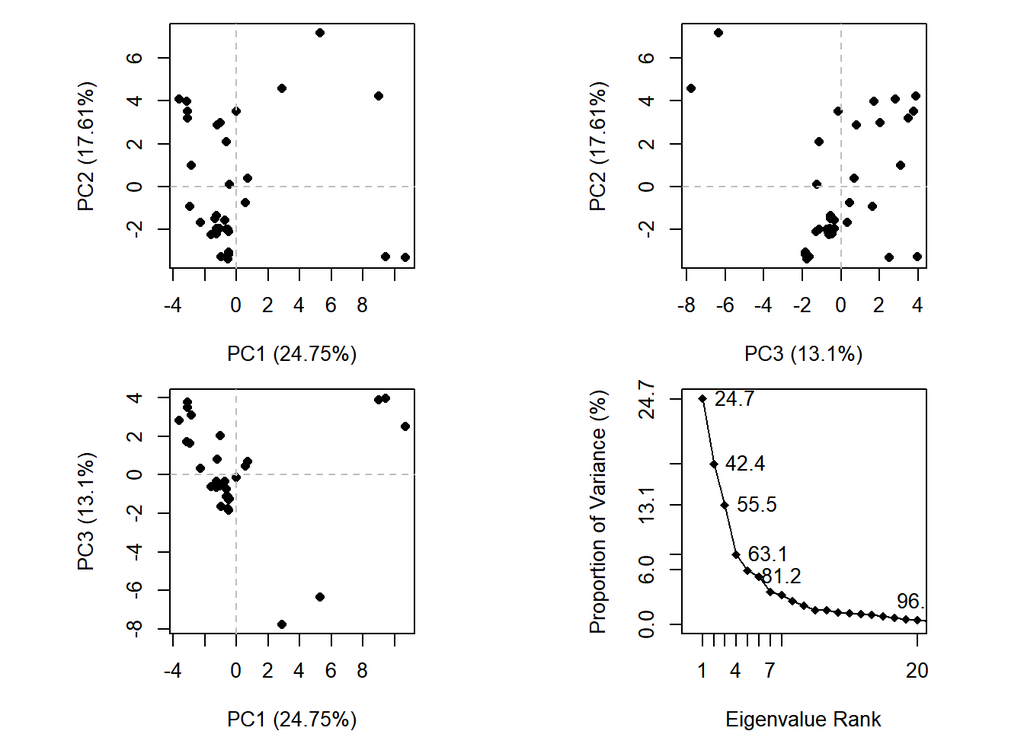

```r
# PCA
pc_lectins <- pca(pdbs)
# Plot results
plot(pc_lectins)
```

```r
# Eigenvalues
L <- pc_lectins$L
# Proportion of variance
pvar_percent <- (L/sum(L)) * 100
# Orthogonal eigenvectors
PCs <- pc_lectins$z
pclabels <- 1:length(PCs[1, ])
for (i in 1:length(PCs[1, ])) {
  pclabels[i] <- paste("PC", i, sep = "")
}
dataset <- as.data.frame(PCs)
colnames(dataset) <- pclabels
# Save the dataset as CSV
write.csv(dataset, file = "dataset.csv", sep = ",", row.names = TRUE,
          col.names = TRUE)
```

# Referências

ALTSCHUL, S. F. et al. Basic local alignment search tool. **Journal of Molecular Biology**, v. 215, p. 403–410, 1990.

EDGAR, R. C. MUSCLE: multiple sequence alignment with high accuracy and high throughput. **Nucleic Acids Research**, v. 32, n. 5, p. 1792–1797, 2004.

GRANT, B. J. et al. Bio3d: an R package for the comparative analysis of protein structures. **Bioinformatics**, v. 22, n. 21, p. 2695–2696, 2006.

GRANT, B. J.; SKJÆRVEN, L.; YAO, X. Q. The Bio3D packages for structural bioinformatics. **Protein Science**, v. 30, n. 1, p. 20–30, 2020.

KONAGURTHU, A. S. et al. MUSTANG: a multiple structural alignment algorithm. **Proteins: Structure, Function and Bioinformatics**, v. 64, p. 559–574, 2006.

R CORE TEAM. **R: A Language and Environment for Statistical Computing**. Vienna, Austria: R Foundation for Statistical Computing, 2021.

RINGNÉR, M. What is principal component analysis? **Nature Biotechnology**, v. 26, n. 3, p. 303–304, 2008.

SKJÆRVEN, L. et al. Integrating protein structural dynamics and evolutionary analysis with Bio3D. **BMC Bioinformatics**, v. 15, n. 1, p. 399, 2014.

[^1]: Universidade Federal do Ceará, pedroqueiroz@alu.ufc.br
[^2]: Universidade Federal do Ceará, brunoanderson@gmail.com
[^3]: Universidade Federal do Ceará, monteiro@lia.ufc.br